# Preliminar anlysis of gene expression data from Brachionus plicatilis

J. Ignacio Lucas Lledó

# Reading the data

The data for this analysis was created in folder 2019-03-29.

```r
args <- commandArgs(trailingOnly = TRUE)
if (length(args) == 0) {
   stop("At least one argument must be supplied: input file.", call.=FALSE)
} else if (length(args) == 1) {
   args[2] <- "."
}

input_file_name <- args[1]
input_file_name
```

```
## [1] "../2019-03-29/isoforms.PostCount.txt"
```

```r
output_dir <- args[2]
counts <- read.table(input_file_name, row.names=1, header=TRUE)
names(counts)
```

```
##  [1] "X1A_S8"  "X1C_S1"  "X2A_S7"  "X2C_S5"  "X3A_S9"  "X3C_S11" "X4A_S6"
##  [8] "X4C_S12" "X5A_S2"  "X5C_S4"  "X6A_S3"  "X6C_S10"
```

Three factors: population, diapause or hatching condition, and selective regime. I set the “immediate hatching” (instead of “forced diapause”) and the “regular” or periodic selective regime as the reference levels of the corresponding factors.

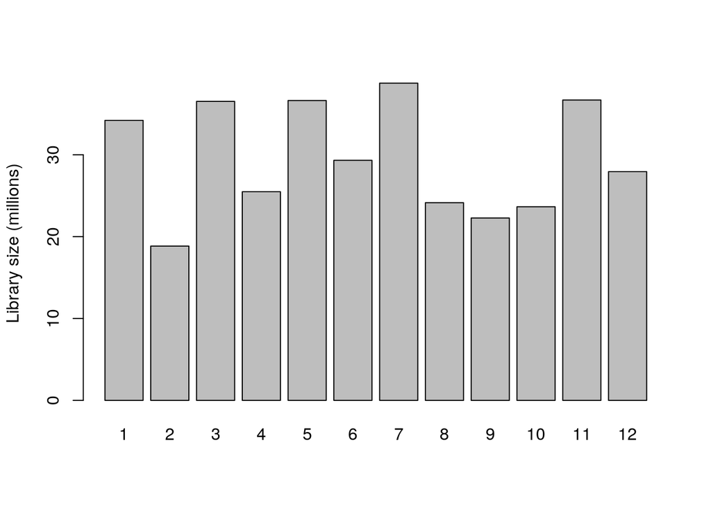

```r
population <- factor(c("1","1","2","2","3","3","4","4","5","5","6","6"))
NestedPop  <- factor(c("1","1","2","2","1","1","3","3","2","2","3","3"))
diapause   <- factor(rep(c("hatch","diapause"), 6))
diapause   <- relevel(diapause, "hatch")
regime     <- factor(c("random","random","random","random","regular","regular",
                 "random","random","regular","regular","regular","regular"))
regime     <- relevel(regime, "regular")
combined   <- factor(c("RandHatch","RandDiap","RandHatch","RandDiap","RegulHatch","RegulDiap",
                      "RandHatch","RandDiap","RegulHatch","RegulDiap","RegulHatch","RegulDiap"))
combined   <- relevel(combined, "RegulHatch")

y <- DGEList(counts=counts, group=regime)
y <- calcNormFactors(y, method="TMM")

barplot(y$samples$lib.size*1e-6, names=1:12, ylab="Library size (millions)")
```

It looks like the populations undergoing diapause systematically produced smaller libraries. It may be the effect of a smaller amount of eggs available. Population 5 is the exception.

# Filtering

The recommended filtering consists on removing genes that have such a low expression level that do not have at least 5-10 counts on as many samples as groups there are. The rationale is that those genes cannot have enough reads in at least one sample of each group. However, instead of filtering on the raw counts, the edgeR manual suggests to translate whatever minimum number of reads per library in terms of counts per million. The reason is that the filtering should take into account differences in library sizes between samples. It probably makes sense, because otherwise, I would be applying an effectively higher (harsher) minimum threshold to the gene expression level in samples with smaller libraries. That would probably bias results, since we would be enriching the dataset in genes more highly expressed in some samples than in others.

Say that library sizes range between 250000 and 2000000. Then, applying a minimum expression level of 20 counts per million is the only way to make sure that even the small libraries are required to contain at least 5 counts, while at the same time setting the cutoff at the same biologically relevant level. In any case, as long as the minimum expression level is not enforced in all samples, the dataset retained will contain genes that do not reach the minimum in some samples. Since counts per million are (expectedly and actually) similarly distributed among samples, it should not be the case that any sample is enriched in low-expression genes.

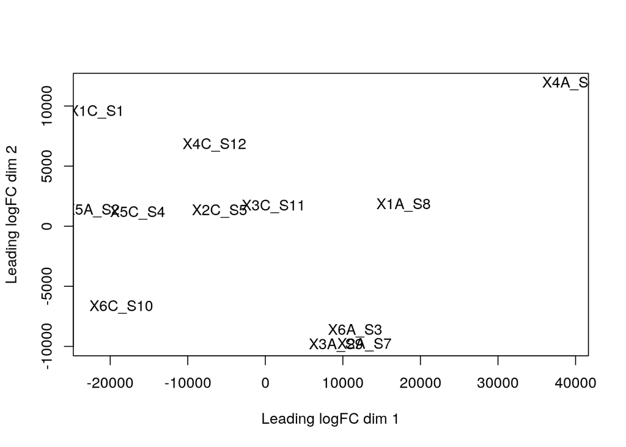

```r
threshold <- 5.0 / (min(y$samples$lib.size) / 1000000)
keep <- rowSums(cpm(y) > threshold) >= 4
y <- y[keep, ,keep.lib.sizes=FALSE]

plotMDS(y$counts)
```

Filtering reduced the number of tags from 77728 to 32925.

The magnitude of variation along the axes seems very high in comparison with the examples available in the EdgeR manual, suggesting wild gene expression differences. With the exception of sample X5A_S2, dimension 1 separates samples undergoing forced diapause (named with a “C”, mostly on the left half of the plot) from those hatching right away (named with an “A”, mostly on the right). The second dimension is also meaningful, since it almost separates populations 1, 2, and 4, which underwent random regime, from 3, 5 and 6 (regular regime). Sample X2A_S7 is the main exception.

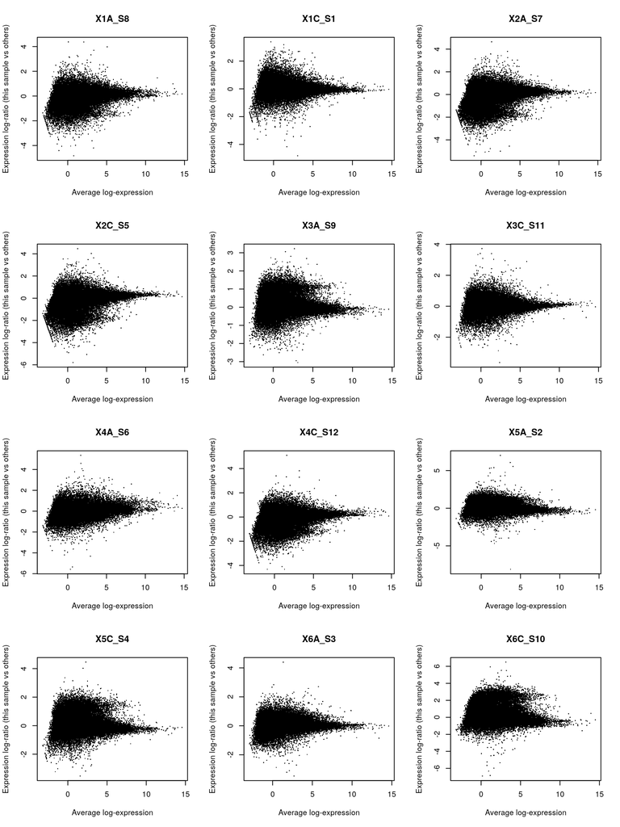

```r
layout(mat=matrix(c(1,2,3,4,5,6,7,8,9,10,11,12), nrow=4, ncol=3, byrow=TRUE), width=c(1,1,1), height=c(1,1,1,1))
for (i in 1:12) {
   plotMD(cpm(y, log=TRUE), column=i)
}
```

```r
layout(mat=matrix(c(1), ncol=1, nrow=1))
```

A lot of genes seem to be differentially expressed. The total number of tags passing the filters is 32925. Let’s define a variable to store this value:

```r
NumOfTags <- dim(y)[1]
```

# Estimating the Biological Coefficient of Variation

I need different models:

- *Model 1.* To test for an effect of the hatching condition, the most powerful model may be this: `~population + diapause`. That is to treet samples as paired by population. By using population, I account for variation due to selective regime.
- *Model 2.* Another simple model would ignore the blocking effect of the population and the interaction between the two main factors: `~regime + diapause`.
- *Model 3.* If there are reasons to ignore the effect of population and the interaction between selective regime and hatching condition, I would combine both factors in one with four levels, following section 3.3.1 in the edgeR manual: `~0 + combined`.
- *Model 4.* Just to check for a batch effect of the population: `~regime + diapause + regime:NestedPop`.
- *Model 5.* For the sake of comparison: `~regime + diapause + regime:diapause`.
- *Model 6.* And for the sake of completeness: `~regime + diapause + regime:diapause + regime:NestedPop`.

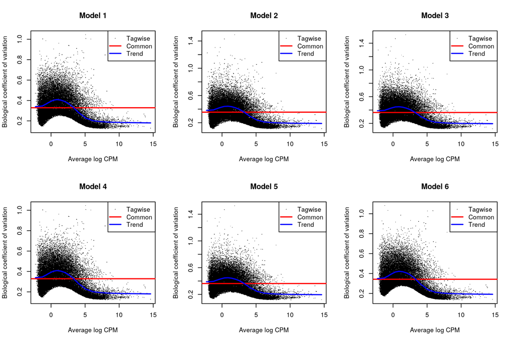

```r
design1 <- model.matrix(~population + diapause)
design2 <- model.matrix(~regime + diapause)
design3 <- model.matrix(~0 + combined)
design4 <- model.matrix(~regime + diapause + regime:NestedPop)
design5 <- model.matrix(~regime + diapause + regime:diapause)
design6 <- model.matrix(~regime + diapause + regime:diapause + regime:NestedPop)

y1 <- estimateDisp(y, design1)
y2 <- estimateDisp(y, design2)
y3 <- estimateDisp(y, design3)
y4 <- estimateDisp(y, design4)
y5 <- estimateDisp(y, design5)
y6 <- estimateDisp(y, design6)

layout(mat=matrix(c(1,2,3,4,5,6), ncol=3, nrow=2, byrow=TRUE))
plotBCV(y1, main='Model 1')
plotBCV(y2, main='Model 2')
plotBCV(y3, main='Model 3')
plotBCV(y4, main='Model 4')
plotBCV(y5, main='Model 5')
plotBCV(y6, main='Model 6')
```

# Fitting the models

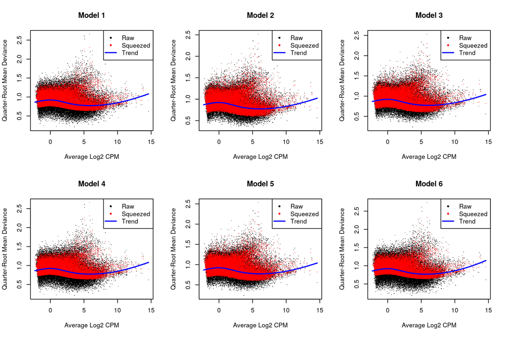

```r
fit1 <- glmQLFit(y1, design1)
fit2 <- glmQLFit(y2, design2)
fit3 <- glmQLFit(y3, design3)
fit4 <- glmQLFit(y4, design4)
fit5 <- glmQLFit(y5, design5)
fit6 <- glmQLFit(y6, design6)

layout(mat=matrix(c(1,2,3,4,5,6), ncol=3, nrow=2, byrow=TRUE))
plotQLDisp(fit1, main='Model 1')
plotQLDisp(fit2, main='Model 2')
plotQLDisp(fit3, main='Model 3')
plotQLDisp(fit4, main='Model 4')
plotQLDisp(fit5, main='Model 5')
plotQLDisp(fit6, main='Model 6')
```

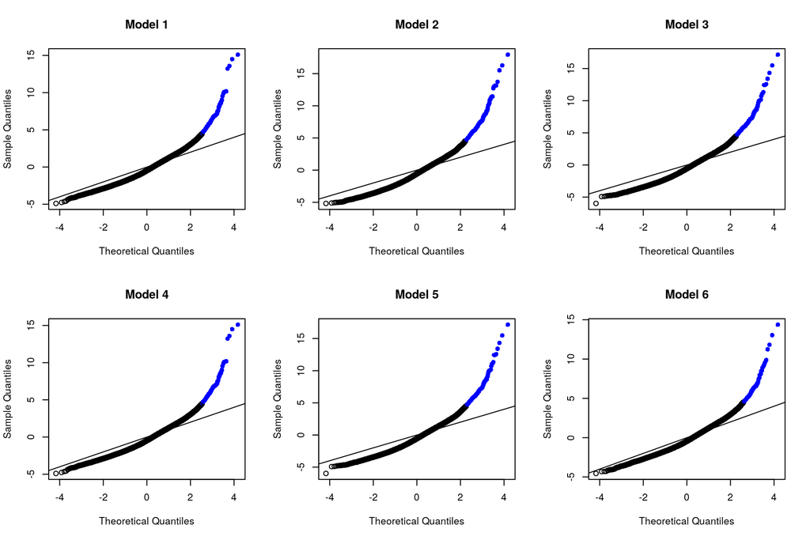

```r
layout(mat=matrix(c(1,2,3,4,5,6), ncol=3, nrow=2, byrow=TRUE))
gof(fit1, plot=TRUE, main='Model 1')
gof(fit2, plot=TRUE, main='Model 2')
gof(fit3, plot=TRUE, main='Model 3')
gof(fit4, plot=TRUE, main='Model 4')
gof(fit5, plot=TRUE, main='Model 5')
gof(fit6, plot=TRUE, main='Model 6')
```

It is clear from the plots above that models including the batch effect of the populations (1, 4, and 6) fit the data better than models that ignore the population effect.

# Cuffdiff results

On 2017-10-27, Eva recorded the genes differentially expressed at FDR 0.05 in four different files. I assume this is the original comparison that generated each file:

- `I1vsI2_all.txt` Immediate hatching versus induced diapause in unpredictable regimes.
- `P1vsP2_all.txt` Immediate hatching versus induced diapause in predictable regimes.
- `I1vsP1_all.txt` Unpredictable versus predictable regimes, when hatching immedately.
- `I2vsP2_all.txt` Unpredictable versus predictable regimes, when inducing diapause.

```r
I1vsI2 <- read.table("../2017-10-27/list_genes/I1vsI2_all.txt",
   colClasses=c("NULL", rep("character", 6), rep("numeric", 6),"factor"),
   col.names=c("ignored","geneid","gene","locus","sample1","sample2","testStat",
   "FPKMx","FPKMy","log2FC","statistic","p","q","significant"))
P1vsP2 <- read.table("../2017-10-27/list_genes/P1vsP2_all.txt",
   colClasses=c("NULL", rep("character", 6), rep("numeric", 6),"factor"),
   col.names=c("ignored","geneid","gene","locus","sample1","sample2","testStat",
   "FPKMx","FPKMy","log2FC","statistic","p","q","significant"))
I1vsP1 <- read.table("../2017-10-27/list_genes/I1vsP1_all.txt",
   colClasses=c("NULL", rep("character", 6), rep("numeric", 6),"factor"),
   col.names=c("ignored","geneid","gene","locus","sample1","sample2","testStat",
   "FPKMx","FPKMy","log2FC","statistic","p","q","significant"))
I2vsP2 <- read.table("../2017-10-27/list_genes/I2vsP2_all.txt",
   colClasses=c("NULL", rep("character", 6), rep("numeric", 6),"factor"),
   col.names=c("ignored","geneid","gene","locus","sample1","sample2","testStat",
   "FPKMx","FPKMy","log2FC","statistic","p","q","significant"))
Cuffdiff_hatching <- I1vsI2$geneid[I1vsI2$geneid %in% P1vsP2$geneid]
Cuffdiff_regime   <- I1vsP1$geneid[I1vsP1$geneid %in% I2vsP2$geneid]
```

There are 69 genes differentially expressed between hatching conditions according to Cuffdiff. Among them, only 0 passed the low expression filter.

There are 3347 gene differentially expressed between selective regimes, according to Cuffdiff. Among them, only 0 passed the low expression filter.